# R Notebook

# Model with cylinder as explanatory variable

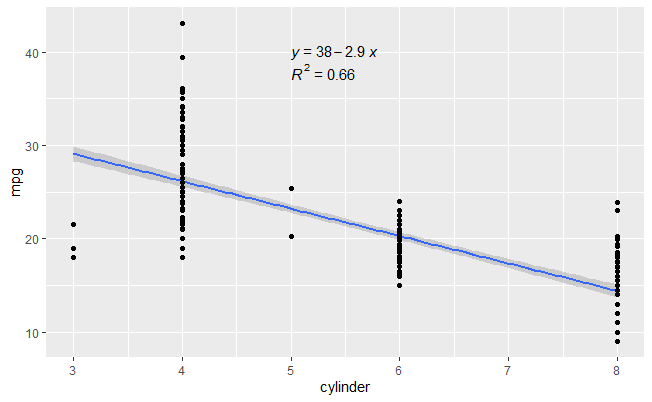

```r
# Linear regression plot
ggplot(data=df_train, aes(x=cylinder, y=mpg)) +
        geom_smooth(method="lm") +
        geom_point() +
        stat_regline_equation(label.x=5, label.y=40) +
        stat_cor(aes(label=..rr.label..), label.x=5, label.y=38)
```

```r
#performing regression
cylinder_model <- lm(mpg~cylinder, data=df_train)
summary(cylinder_model)
```

```
Call:
lm(formula = mpg ~ cylinder, data = df_train)

Residuals:
     Min       1Q   Median       3Q      Max
-11.1071  -2.3012  -0.4306   1.8282  16.9282

Coefficients:
            Estimate Std. Error t value Pr(>|t|)
(Intercept)  37.9130     0.7356   51.54   <2e-16 ***
cylinder     -2.9353     0.1211  -24.24   <2e-16 ***
---
Signif. codes:  0 ‘***’ 0.001 ‘**’ 0.01 ‘*’ 0.05 ‘.’ 0.1 ‘ ’ 1

Residual standard error: 3.678 on 298 degrees of freedom
Multiple R-squared:  0.6636,    Adjusted R-squared:  0.6624
F-statistic: 587.8 on 1 and 298 DF,  p-value: < 2.2e-16
```

```r
# mean of residuals
mean(resid(cylinder_model))
```

```
[1] -4.930084e-17
```

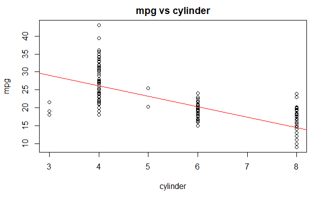

```r
#plot the variable
plot(df_train$mpg~df_train$cylinder,main="mpg vs cylinder",xlab="cylinder",ylab = "mpg")
abline(cylinder_model,col="red")
```

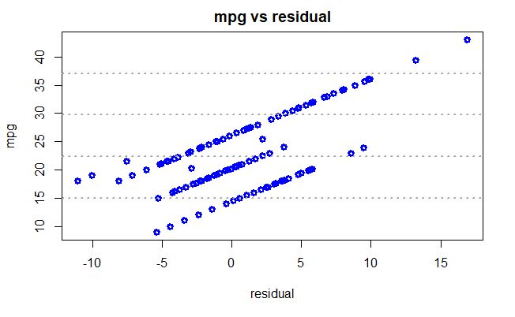

```r
#residuals vs. the predictor variable
residual <- cylinder_model$residuals
plot(df_train$mpg~residual,lwd=3, col="blue",main="mpg vs residual", xlab="residual",ylab = "mpg")
grid(NA, 5, lwd = 2,col = "darkgray")
```

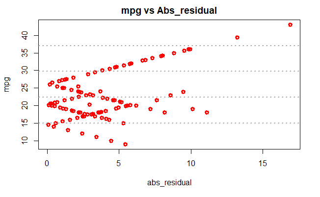

```r
#absolute value of the residuals vs. the predictor variable
abs_residual <- abs(residual)
plot(df_train$mpg~abs_residual,lwd=3, col="red",main="mpg vs Abs_residual", xlab="abs_residual",ylab = "mpg")
grid(NA, 5, lwd = 2,col = "darkgray")
```

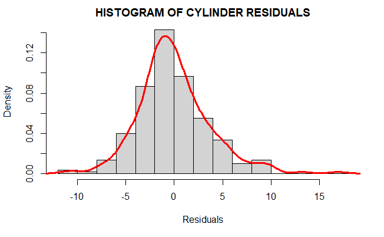

```r
#histogram of the residuals
hist(residual,prob=T,breaks=20,main="HISTOGRAM OF CYLINDER RESIDUALS",xlab="Residuals")
lines(density(residual),col="red",lwd=3)
```

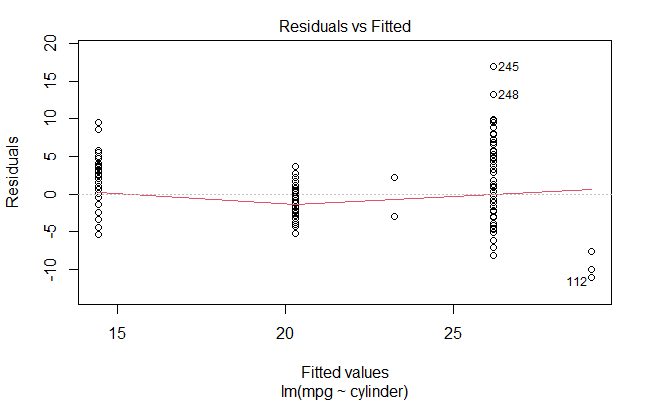

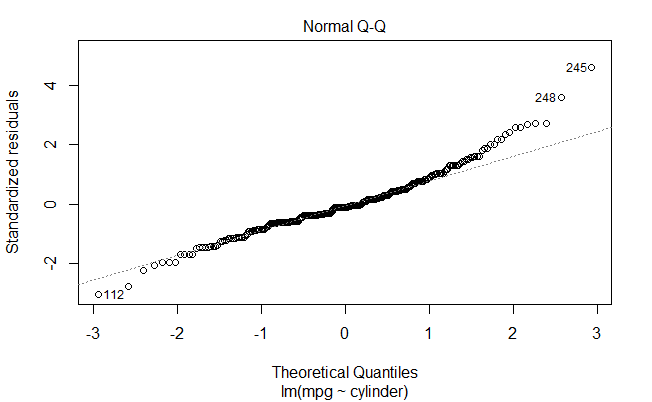

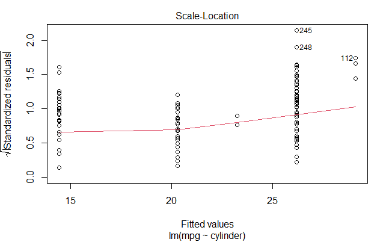

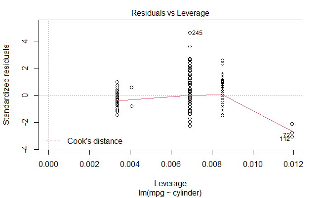

```r
plot(cylinder_model)
```

```r
# Make predictions and compute the R2, RMSE and MAE
cyl_predict <- cylinder_model %>% predict(df_test)
data.frame( R2 = R2(cyl_predict, df_test$mpg),
            RMSE = RMSE(cyl_predict, df_test$mpg),
            MAE = MAE(cyl_predict, df_test$mpg))
```

| R2 | RMSE | MAE |
| --- | --- | --- |
| 0.1829322 | 8.611541 | 7.099133 |

```r
prediction_error = RMSE(cyl_predict, df_test$mpg)/mean(df_test$mpg)
prediction_error
```

```
[1] 0.2695685
```

```r
compare_cyl = as.data.frame(cbind(df_test$mpg,cyl_predict),row=FALSE)
names(compare_cyl) = c("observed","cyl_predict")
head(compare_cyl)
```

|  | observed | cyl_predict |
| --- | --- | --- |
| 1 | 34.5 | 26.17179 |
| 2 | 31.8 | 26.17179 |
| 3 | 37.3 | 26.17179 |
| 4 | 28.4 | 26.17179 |
| 5 | 28.8 | 20.30120 |
| 6 | 26.8 | 20.30120 |

*In this model all the estimated values are statistically significant with a p-value less than 2e-16 . It is shown that the plot of MPG vs the cylinder is not linear and there is a sort of non-linear relationship between the variable and the residual. This model is definitely not the ideal one. The diagnostic plot reveal that these following data point 245,248,112 are outliers. The adjusted R-square state that 66.24 % of cylinder explain MPG.*

# Model with weight as explanatory variable

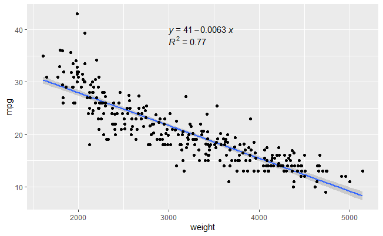

```r
# Linear regression plot
ggplot(data=df_train, aes(x=weight, y=mpg)) +
        geom_smooth(method="lm") +
        geom_point() +
        stat_regline_equation(label.x=3000, label.y=40) +
        stat_cor(aes(label=..rr.label..), label.x=3000, label.y=38)
```

```r
#performing regression
weight_model <- lm(mpg~weight, data=df_train)
summary(weight_model)
```

```
Call:
lm(formula = mpg ~ weight, data = df_train)

Residuals:
    Min      1Q  Median      3Q     Max
-9.2011 -1.9157 -0.0812  1.7341 15.0246

Coefficients:
              Estimate Std. Error t value Pr(>|t|)
(Intercept) 40.5619792  0.6461532   62.77   <2e-16 ***
weight      -0.0062905  0.0001984  -31.71   <2e-16 ***
---
Signif. codes:  0 ‘***’ 0.001 ‘**’ 0.01 ‘*’ 0.05 ‘.’ 0.1 ‘ ’ 1

Residual standard error: 3.032 on 298 degrees of freedom
Multiple R-squared:  0.7714,    Adjusted R-squared:  0.7706
F-statistic:  1005 on 1 and 298 DF,  p-value: < 2.2e-16
```

```r
# mean of residuals
mean(resid(weight_model))
```

```
[1] 2.543538e-16
```

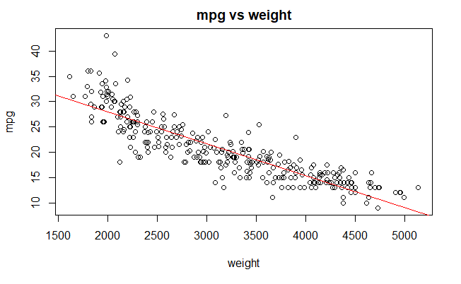

```r
#plot the variable
plot(df_train$mpg~df_train$weight,main="mpg vs weight",xlab="weight",ylab = "mpg")
abline(weight_model,col="red")
```

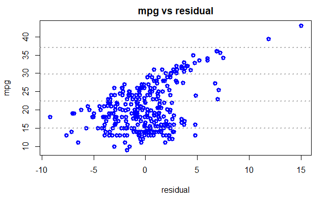

```r
#residuals vs. the predictor variable
residual <- weight_model$residuals
plot(df_train$mpg~residual,lwd=3, col="blue",main="mpg vs residual", xlab="residual",ylab = "mpg")
grid(NA, 5, lwd = 2,col = "darkgray")
```

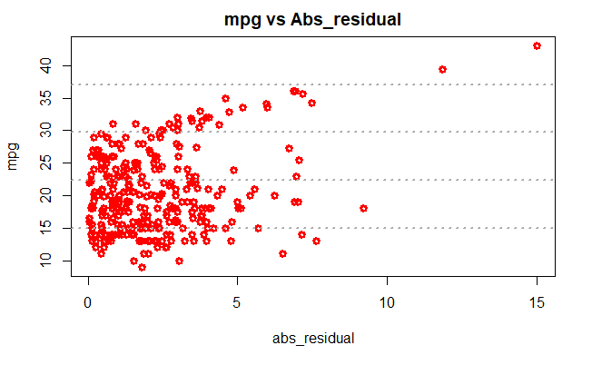

```r
#absolute value of the residuals vs. the predictor variable
abs_residual <- abs(residual)
plot(df_train$mpg~abs_residual,lwd=3, col="red",main="mpg vs Abs_residual", xlab="abs_residual",ylab = "mpg")
grid(NA, 5, lwd = 2,col = "darkgray")
```

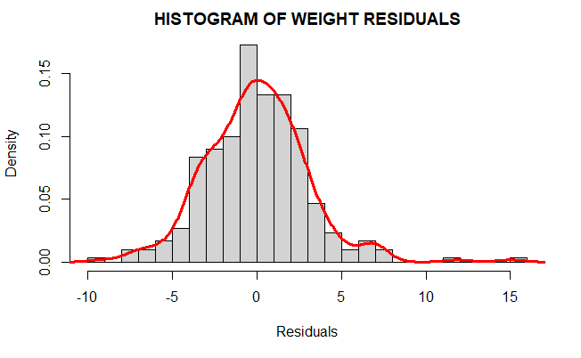

```r
#histogram of the residuals
hist(residual,prob=T,breaks=20,main="HISTOGRAM OF WEIGHT RESIDUALS",xlab="Residuals")
lines(density(residual),col="red",lwd=3)
```

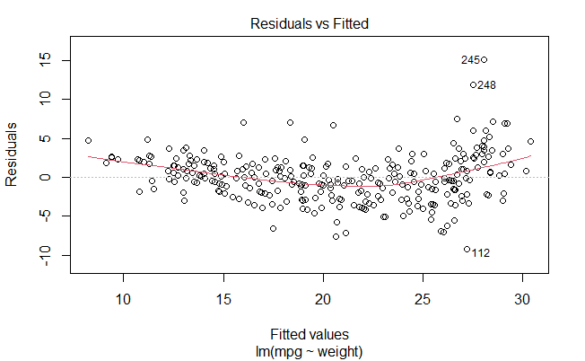

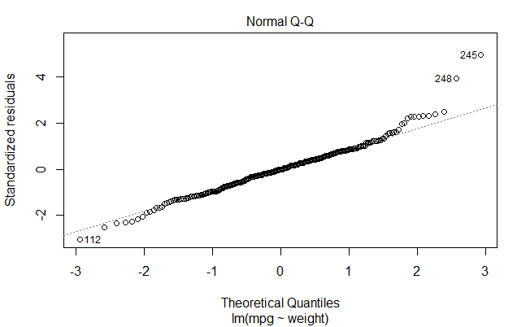

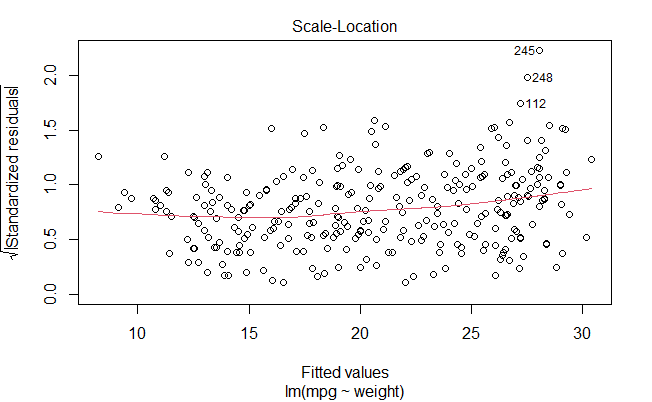

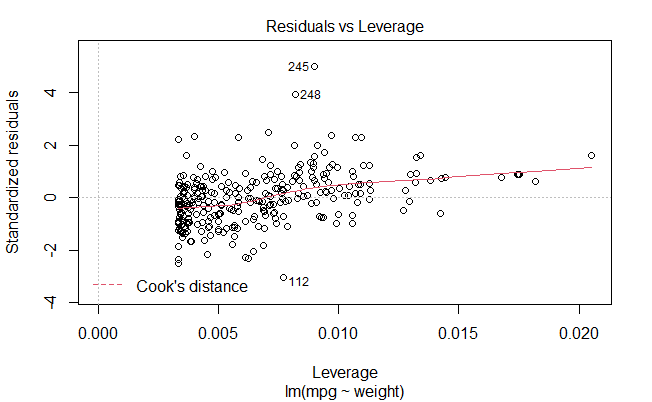

```r
plot(weight_model)
```

```r
# Make predictions and compute the R2, RMSE and MAE
weight_predict <- weight_model %>% predict(df_test)
data.frame( R2 = R2(weight_predict, df_test$mpg),
            RMSE = RMSE(weight_predict, df_test$mpg),
            MAE = MAE(weight_predict, df_test$mpg))
```

| R2 | RMSE | MAE |
| --- | --- | --- |
| 0.5006516 | 8.157758 | 6.983514 |

```r
prediction_error = RMSE(weight_predict, df_test$mpg)/mean(df_test$mpg)
prediction_error
```

```
[1] 0.2553637
```

[output not shown]

*In this model all the estimated values are statistically significant with a p-value less than 2e-16 . It is shown that the plot of MPG vs the weight is not linear and there is a sort of non-linear relationship between the variable and the residual. This model is definitely not the ideal one. The diagnostic plot reveal that these following data point 245,248,112 are outliers. The adjusted R-square state that 77.06% of weight explain MPG.*

# Model with acceleration as explanatory variable

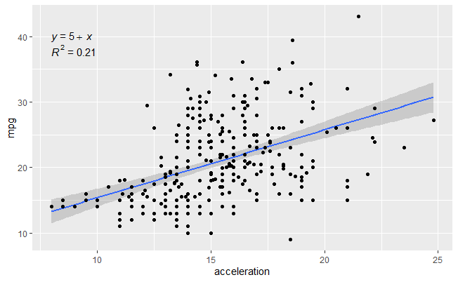

```r
# Linear regression plot
ggplot(data=df_train, aes(x=acceleration, y=mpg)) +
        geom_smooth(method="lm") +
        geom_point() +
        stat_regline_equation(label.x=8, label.y=40) +
        stat_cor(aes(label=..rr.label..), label.x=8, label.y=38)
```

```r
#performing regression
acc_model <- lm(mpg~acceleration, data=df_train)
summary(acc_model)
```

```
Call:
lm(formula = mpg ~ acceleration, data = df_train)

Residuals:
    Min      1Q  Median      3Q     Max
-15.202  -4.126  -1.012   3.268  16.154

Coefficients:
             Estimate Std. Error t value Pr(>|t|)
(Intercept)    5.0012     1.8352   2.725  0.00681 **
acceleration   1.0379     0.1183   8.770  < 2e-16 ***
---
Signif. codes:  0 ‘***’ 0.001 ‘**’ 0.01 ‘*’ 0.05 ‘.’ 0.1 ‘ ’ 1

Residual standard error: 5.654 on 298 degrees of freedom
Multiple R-squared:  0.2052,    Adjusted R-squared:  0.2025
F-statistic: 76.91 on 1 and 298 DF,  p-value: < 2.2e-16
```

```r
# mean of residuals
mean(resid(acc_model))
```

```
[1] -6.274957e-16
```

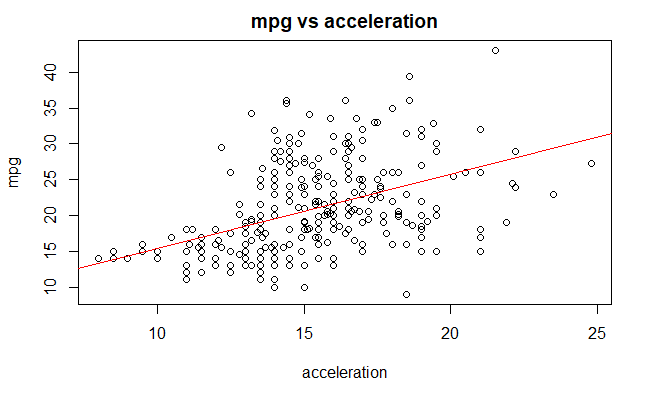

```r
#plot the variable
plot(df_train$mpg~df_train$acceleration,main="mpg vs acceleration",xlab="acceleration",ylab = "mpg")
abline(acc_model,col="red")
```

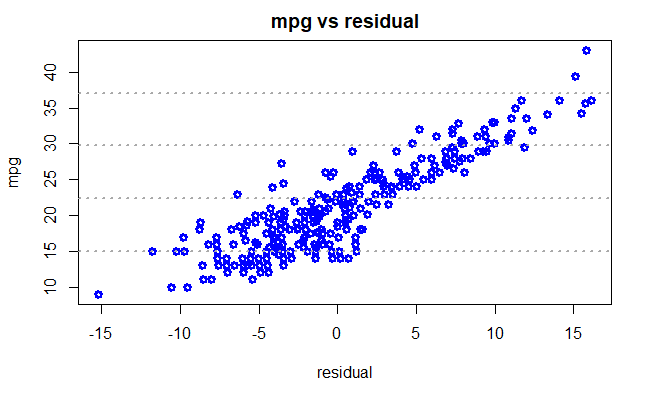

```r
#residuals vs. the predictor variable
residual <- acc_model$residuals
plot(df_train$mpg~residual,lwd=3, col="blue",main="mpg vs residual", xlab="residual",ylab = "mpg")
grid(NA, 5, lwd = 2,col = "darkgray")
```

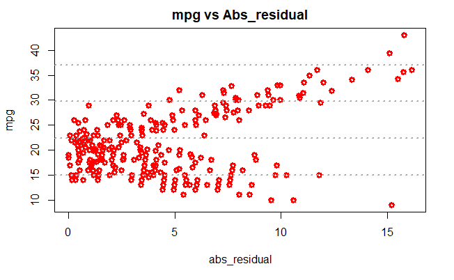

```r
#absolute value of the residuals vs. the predictor variable
abs_residual <- abs(residual)
plot(df_train$mpg~abs_residual,lwd=3, col="red",main="mpg vs Abs_residual", xlab="abs_residual",ylab = "mpg")
grid(NA, 5, lwd = 2,col = "darkgray")
```

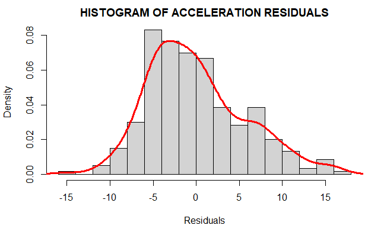

```r
#histogram of the residuals
hist(residual,prob=T,breaks=20,main="HISTOGRAM OF ACCELERATION RESIDUALS",xlab="Residuals")
lines(density(residual),col="red",lwd=3)
```

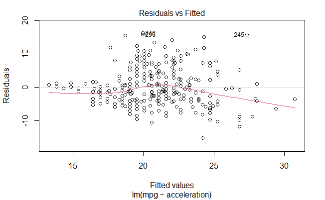

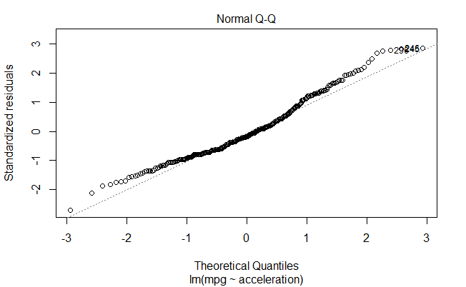

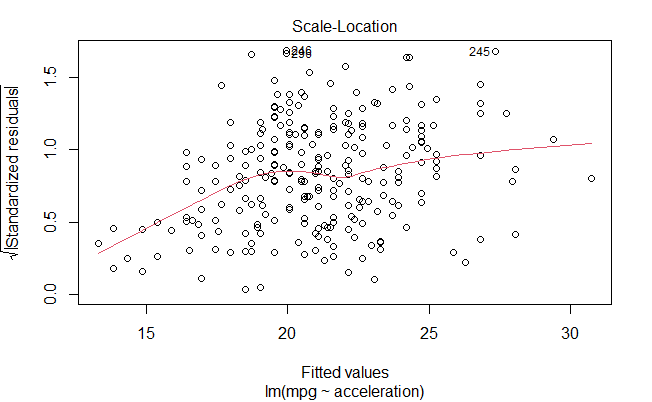

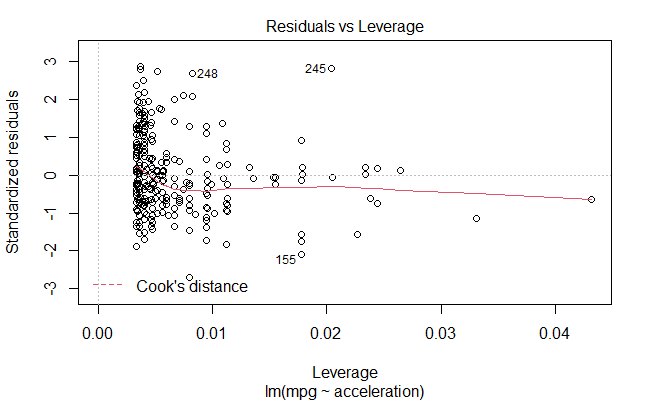

```r
plot(acc_model)
```

```r
# Make predictions and compute the R2, RMSE and MAE
acc_predict <- acc_model %>% predict(df_test)
data.frame( R2 = R2(acc_predict, df_test$mpg),
            RMSE = RMSE(acc_predict, df_test$mpg),
            MAE = MAE(acc_predict, df_test$mpg))
```

| R2 | RMSE | MAE |
| --- | --- | --- |
| 0.03597167 | 11.51665 | 10.16914 |

```r
prediction_error = RMSE(acc_predict, df_test$mpg)/mean(df_test$mpg)
prediction_error
```

```
[1] 0.3605077
```

[output not shown]

# Multiple regression

## Feature selection

### Stepwise regression

```r
# To find out which independent variable to use in our multiple regression we are going to use the step wise regression
null=lm(mpg~1,data=df_train)
full=lm(mpg~.,data=df_train)
step(null,scope=list(upper=full),data=df_train,direction="both")
```

```
Start:  AIC=1108.25
mpg ~ 1

               Df Sum of Sq     RSS     AIC
+ weight        1    9243.7  2739.6  667.54
+ displacement  1    8513.2  3470.1  738.45
+ cylinder      1    7951.8  4031.5  783.43
+ horsepower    1    7680.7  4302.6  802.96
+ acceleration  1    2458.4  9524.9 1041.36
<none>                      11983.3 1108.25

Step:  AIC=667.54
mpg ~ weight

               Df Sum of Sq     RSS     AIC
+ horsepower    1      98.2  2641.5  658.59
+ displacement  1      59.9  2679.7  662.91
+ acceleration  1      41.1  2698.6  665.01
+ cylinder      1      34.9  2704.8  665.70
<none>                       2739.6  667.54
- weight        1    9243.7 11983.3 1108.25

Step:  AIC=658.59
mpg ~ weight + horsepower

               Df Sum of Sq    RSS    AIC
<none>                      2641.5 658.59
+ cylinder      1     10.65 2630.8 659.38
+ displacement  1      9.81 2631.7 659.48
+ acceleration  1      1.00 2640.5 660.48
- horsepower    1     98.16 2739.6 667.54
- weight        1   1661.08 4302.6 802.96

Call:
lm(formula = mpg ~ weight + horsepower, data = df_train)

Coefficients:
(Intercept)       weight   horsepower
  40.258743    -0.005204    -0.027759
```

*As shown in the R results above the step function produced weight and horsepower as the optimum variables to produce the desired linear regression model . This step function use AIC as criterion. It selects the combination of variables with which we can have the lower AIC statistic.This would be our final model.*

# Building the final model

```r
final_model <- lm(mpg ~ weight + horsepower, data = df_train)
summary(final_model)
```

```
Call:
lm(formula = mpg ~ weight + horsepower, data = df_train)

Residuals:
    Min      1Q  Median      3Q     Max
-8.7069 -1.8380  0.0207  1.6877 14.5038

Coefficients:
              Estimate Std. Error t value Pr(>|t|)
(Intercept) 40.2587429  0.6420610  62.702  < 2e-16 ***
weight      -0.0052041  0.0003808 -13.666  < 2e-16 ***
horsepower  -0.0277594  0.0083560  -3.322  0.00101 **
---
Signif. codes:  0 ‘***’ 0.001 ‘**’ 0.01 ‘*’ 0.05 ‘.’ 0.1 ‘ ’ 1

Residual standard error: 2.982 on 297 degrees of freedom
Multiple R-squared:  0.7796,    Adjusted R-squared:  0.7781
F-statistic: 525.2 on 2 and 297 DF,  p-value: < 2.2e-16
```

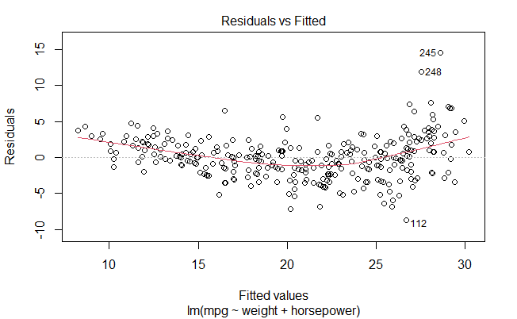

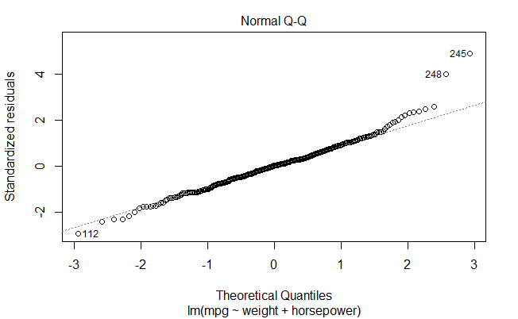

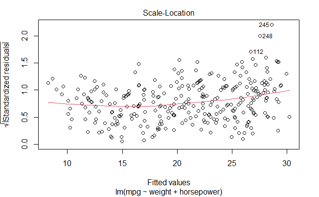

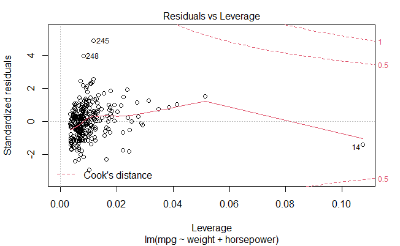

```r
plot(final_model)
```

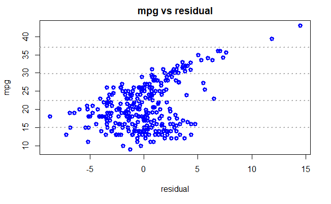

```r
#residuals vs. the predictor variable
residual <- final_model$residuals
plot(df_train$mpg~residual,lwd=3, col="blue",main="mpg vs residual", xlab="residual",ylab = "mpg")
grid(NA, 5, lwd = 2,col = "darkgray")
```

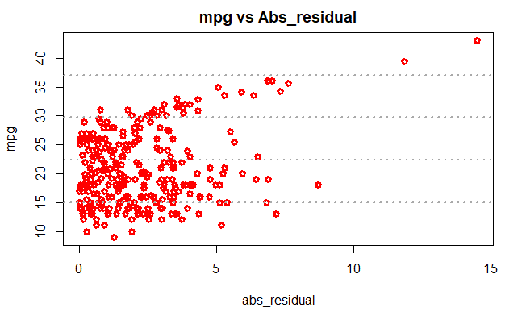

```r
#absolute value of the residuals vs. the predictor variable
abs_residual <- abs(residual)
plot(df_train$mpg~abs_residual,lwd=3, col="red",main="mpg vs Abs_residual", xlab="abs_residual",ylab = "mpg")
grid(NA, 5, lwd = 2,col = "darkgray")
```

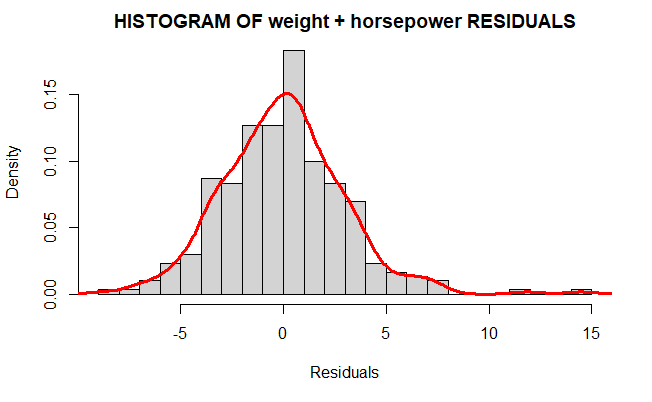

```r
#histogram of the residuals
hist(residual,prob=T,breaks=20,main="HISTOGRAM OF weight + horsepower RESIDUALS",xlab="Residuals")
lines(density(residual),col="red",lwd=3)
```

```r
# Global Validation of Linear Models Assumptions
gvlma(final_model)
```

```
Call:
lm(formula = mpg ~ weight + horsepower, data = df_train)

Coefficients:
(Intercept)       weight   horsepower
  40.258743    -0.005204    -0.027759


ASSESSMENT OF THE LINEAR MODEL ASSUMPTIONS
USING THE GLOBAL TEST ON 4 DEGREES-OF-FREEDOM:
Level of Significance =  0.05

Call:
 gvlma(x = final_model)
```

|  | Value | p-value | Decision |
| --- | --- | --- | --- |
| Global Stat | 150.773665 | 0.000000e+00 | Assumptions NOT satisfied! |
| Skewness | 16.364708 | 5.224912e-05 | Assumptions NOT satisfied! |
| Kurtosis | 59.193136 | 1.432188e-14 | Assumptions NOT satisfied! |
| Link Function | 65.956767 | 4.440892e-16 | Assumptions NOT satisfied! |
| Heteroscedasticity | 9.259055 | 2.343339e-03 | Assumptions NOT satisfied! |

*None of the assumptions are satisfied. This could be due to the fact that we have some outliers in the data that can impact the quality of the model. Let’s remove them from the data then see what happen.*

```r
final_model2 <- lm(mpg ~ weight + horsepower, data = df_train[-c(112,245,248),])
summary(final_model2)
```

```
Call:
lm(formula = mpg ~ weight + horsepower, data = df_train[-c(112,
    245, 248), ])

Residuals:
    Min      1Q  Median      3Q     Max
-8.7327 -1.7911  0.0047  1.6783 14.5074

Coefficients:
              Estimate Std. Error t value Pr(>|t|)
(Intercept) 40.2859314  0.6408855  62.860  < 2e-16 ***
weight      -0.0052394  0.0003785 -13.844  < 2e-16 ***
horsepower  -0.0269430  0.0083047  -3.244  0.00131 **
---
Signif. codes:  0 ‘***’ 0.001 ‘**’ 0.01 ‘*’ 0.05 ‘.’ 0.1 ‘ ’ 1

Residual standard error: 2.96 on 294 degrees of freedom
Multiple R-squared:  0.7824,    Adjusted R-squared:  0.7809
F-statistic: 528.6 on 2 and 294 DF,  p-value: < 2.2e-16
```

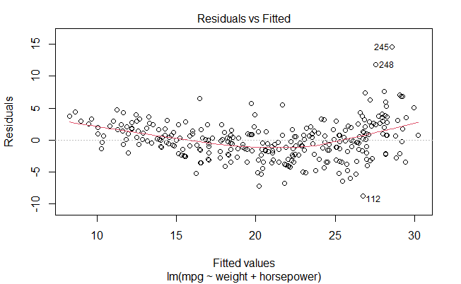

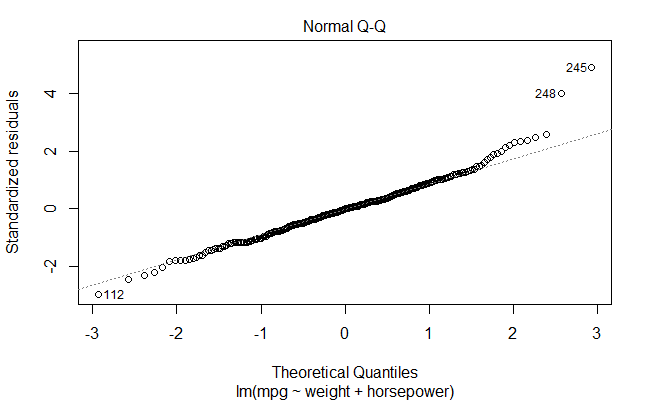

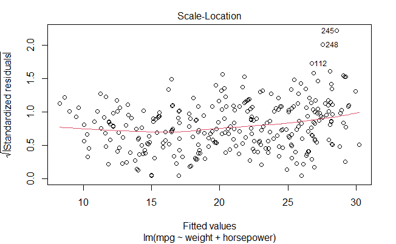

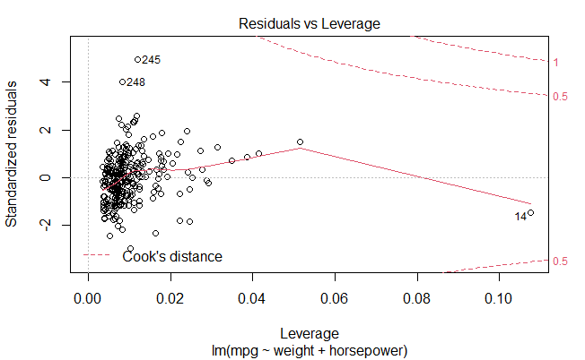

```r
plot(final_model2)
```

```r
# Global Validation of Linear Models Assumptions
gvlma(final_model2)
```

```
Call:
lm(formula = mpg ~ weight + horsepower, data = df_train[-c(112,
    245, 248), ])

Coefficients:
(Intercept)       weight   horsepower
  40.285931    -0.005239    -0.026943


ASSESSMENT OF THE LINEAR MODEL ASSUMPTIONS
USING THE GLOBAL TEST ON 4 DEGREES-OF-FREEDOM:
Level of Significance =  0.05

Call:
 gvlma(x = final_model2)
```

|  | Value | p-value | Decision |
| --- | --- | --- | --- |
| Global Stat | 158.36729 | 0.000000e+00 | Assumptions NOT satisfied! |
| Skewness | 18.69113 | 1.536958e-05 | Assumptions NOT satisfied! |
| Kurtosis | 64.02011 | 1.221245e-15 | Assumptions NOT satisfied! |
| Link Function | 65.56500 | 5.551115e-16 | Assumptions NOT satisfied! |
| Heteroscedasticity | 10.09105 | 1.489913e-03 | Assumptions NOT satisfied! |

*We notice that even if we remove the outlier the linear model assumptions are not satisfied. R-squared and adjusted R-squared values did not improve much even after removing the outliers. We suspect that a non linear model would perform better on this car data.*